# Project 2

Josh Stim

2023-09-24

# Exploring Temperature and Rainfall in Australia

## Part 0. Setting up

Install tidyverse and tidytuesdayR packages

Load tidyverse and tidytuesdayR packages

```r
library(tidyverse)
library(tidytuesdayR)
library(here)
library(dplyr)
```

## Part 1. Fun with functions

### (a) Exponential Transformation

Write a function that computes the exponential of a number using the truncated series expansion. The function should take two arguments:

`x`: the number to be exponentiated

`k`: the number of terms to be used in the series expansion beyond the constant 1. The value of `k` is always $\geq 1$

**Josh:** Below is a recursive function that uses `k` terms to approximate `exp(x)`.

```r
Exp <- function(x, k) {
  if (k == 0) {
    return(1)
  } else {
    return(Exp(x,k-1) + (x**k / factorial(k)))
  }
}
```

**Josh:** Below is a demonstration of `Exp()` in comparison to `exp()`.

```r
################################################################################
# Demonstration of Exp(n,k)
################################################################################
cat(noquote("Output from Exp(2,15):\n"))
Exp(2,15)
cat("\n")

################################################################################
# Demonstration of exp(n)
################################################################################
cat(noquote("Output from exp(2):\n"))
exp(2)
```

```
## Output from Exp(2,15):
## [1] 7.389056
##
## Output from exp(2):
## [1] 7.389056
```

### (b) Sample mean and sample standard deviation

Next, write two functions called `sample_mean()` and `sample_sd()` that takes as input a vector of data of length and calculates the sample average and sample standard deviation for the set of observations.

**Josh:** Below is a function that computes the sample mean and standard deviation, given a numeric vector.

```r
sample_mean <- function(x) {
  a <- rep(1 / length(x), length(x))
  return(as.double(x %*% a))
}

sample_sd <- function(x) {
  x_bar <- sample_mean(x)
  sample_var <- as.double(((x - x_bar) %*% (x - x_bar)) / (length(x) - 1))
  return(sqrt(sample_var))
}
```

**Josh:** Below is a demonstraction of `sample_mean` and `sample_sd`.

```r
x <- c(1:10)    # define numeric vector

################################################################################
# Demonstration of sample_mean() and sample_sd()
################################################################################
cat(noquote("Output from sample_mean(x) and sample_sd(x):\n"))
sample_mean(x)
sample_sd(x)
cat("\n")

################################################################################
# Demonstration of mean() and sd()
################################################################################
cat(noquote("Output from mean(x) and sd(x):\n"))
mean(x)
sd(x)
```

```
## Output from sample_mean(x) and sample_sd(x):
## [1] 5.5
## [1] 3.02765
##
## Output from mean(x) and sd(x):
## [1] 5.5
## [1] 3.02765
```

### (c) Confidence intervals

Next, write a function called calculate_CI() that:

1. There should be two inputs to the `calculate_CI()`. First, it should take as input a vector of data of length $N$. Second, the function should also have a `conf` ($=1-\alpha$) argument that allows the confidence interval to be adapted for different $\alpha$.
2. Calculates a confidence interval (CI) (e.g. a 95% CI) for the estimate of the mean in the population. If you are not familiar with confidence intervals, it is an interval that contains the population parameter with probability $1-\alpha$ taking on this form

$$\begin{align*}
\bar{x} &\pm t_{\alpha \backslash 2, N-1}s{\bar{x}}
\end{align*}$$
where $t_{\alpha \backslash 2, N-1}$ is the value needed to generate an area of $\alpha \backslash 2$ in each tail of the $t$-distribution with $N-1$ degrees of freedom and $s_{\bar{x}} = \frac{s}{\sqrt{N}}$ is the standard error of the mean.

3. Returns a named vector of length 2, where the first value is the `lower_bound`, the second value is the `upper_bound`.

**Josh:** Below is a function that calculate the confidence interval given a numeric vector and level of confidence.

```r
calculate_CI <- function(x, conf = 0.95) {
  N <- length(x)                                        # number of observations
  alpha <- 1 - conf                                     # specify alpha

  x_bar <- sample_mean(x)                               # compute sample mean
  sem <- sample_sd(x) / sqrt(N)                         # compute SEM
  t <- qt(alpha / 2, df = N - 1, lower.tail = FALSE)    # compute critical t-value

  conf_int <- c(x_bar - t*sem, x_bar + t*sem)           # confidence interval
  names(conf_int) <- c("lower_bound", "upper_bound")

  return(conf_int)               # return confidence interval
}
```

**Josh:** Below is a demonstration of `calculate_CI` in comparison to `confint` using an alpha of `0.10` and `0.05`.

```r
################################################################################
# Demonstration of calculate_CI with conf1 = 0.90 and conf2 = 0.95
################################################################################
x <- c(1:15)                                # specify a data vector
conf1 <- 0.90
conf2 <- 0.95                                # what level of confidence we want

cat(noquote("Output from calculate_CI(x, conf = 0.90):\n"))
calculate_CI(x, conf1)                      # calculate_CI demo
cat("\n")

cat(noquote("Output from calculate_CI(x, conf = 0.95):\n"))
calculate_CI(x, conf2)
cat("\n")

################################################################################
# Demonstration of confint using conf1 = 0.90 and conf2 = 0.95
################################################################################
df <- data.frame(x = x)                 # convert data to data.frame
fit <- lm(x ~ 1, df)                    # fit data to simple linear model (intercept only)

cat(noquote("Output from confint(fit, level = 0.90):\n"))
confint(fit, level = conf1)              # confint demo
cat("\n")

cat(noquote("Output from confint(fit, level = 0.95):\n"))
confint(fit, level = conf2)
```

```
## Output from calculate_CI(x, conf = 0.90):
## lower_bound upper_bound
##    5.966214   10.033786
##
## Output from calculate_CI(x, conf = 0.95):
## lower_bound upper_bound
##    5.523414   10.476586
##
## Output from confint(fit, level = 0.90):
##                  5 %     95 %
## (Intercept) 5.966214 10.03379
##
## Output from confint(fit, level = 0.95):
##                2.5 %   97.5 %
## (Intercept) 5.523414 10.47659
```

## Part 2. Wrangling Data

```
## Rows: 179,273
## Columns: 11
## $ station_code <chr> "009151", "009151", "009151", "009151", "009151", "009151…
## $ city_name    <chr> "Perth", "Perth", "Perth", "Perth", "Perth", "Perth", "Pe…
## $ year         <dbl> 1967, 1967, 1967, 1967, 1967, 1967, 1967, 1967, 1967, 196…
## $ month        <chr> "01", "01", "01", "01", "01", "01", "01", "01", "01", "01…
## $ day          <chr> "01", "02", "03", "04", "05", "06", "07", "08", "09", "10…
## $ rainfall     <dbl> NA, NA, NA, NA, NA, NA, NA, NA, NA, NA, NA, NA, NA, NA, N…
## $ period       <dbl> NA, NA, NA, NA, NA, NA, NA, NA, NA, NA, NA, NA, NA, NA, N…
## $ quality      <chr> NA, NA, NA, NA, NA, NA, NA, NA, NA, NA, NA, NA, NA, NA, N…
## $ lat          <dbl> -31.96, -31.96, -31.96, -31.96, -31.96, -31.96, -31.96, -…
## $ long         <dbl> 115.79, 115.79, 115.79, 115.79, 115.79, 115.79, 115.79, 1…
## $ station_name <chr> "Subiaco Wastewater Treatment Plant", "Subiaco Wastewater…
```

```
## Rows: 528,278
## Columns: 5
## $ city_name   <chr> "PERTH", "PERTH", "PERTH", "PERTH", "PERTH", "PERTH", "PER…
## $ date        <date> 1910-01-01, 1910-01-02, 1910-01-03, 1910-01-04, 1910-01-0…
## $ temperature <dbl> 26.7, 27.0, 27.5, 24.0, 24.8, 24.4, 25.3, 28.0, 32.6, 35.9…
## $ temp_type   <chr> "max", "max", "max", "max", "max", "max", "max", "max", "m…
## $ site_name   <chr> "PERTH AIRPORT", "PERTH AIRPORT", "PERTH AIRPORT", "PERTH …
```

### Tasks

Using the rainfall and temperature data, perform the following steps and create a new data frame called df:

1. Start with `rainfall` dataset and drop any rows with NAs.
2. Create a new column titled `date` that combines the columns `year`, `month`, `day` into one column separated by “-”. (e.g. “2020-01-01”). This column should not be a character, but should be recognized as a date. (Hint: check out the `ymd()` function in `lubridate` R package). You will also want to add a column that just keeps the `year`.
3. Using the `city_name` column, convert the city names (character strings) to all upper case.
4. Join this wrangled rainfall dataset with the `temperature` dataset such that it includes only observations that are in both data frames. (Hint: there are two keys that you will need to join the two datasets together). (Hint: If all has gone well thus far, you should have a dataset with 83,964 rows and 13 columns).

**Josh:** Below is my solution to merging the `tempurature` and `rainfall` dataframes.

```r
################################################################################
# Modify rainfall dataset based task description
################################################################################
rainfall.mod <- drop_na(rainfall) %>%                        # drop any rows that contain an NA
  mutate(date = ymd(paste(year, month, day, sep = "-"))) %>% # create date column using yyyy-mm-dd format
  mutate(month = NULL, day = NULL) %>%                       # remove the month and day columns
  mutate(city_name = str_to_upper(city_name))                # change city names to all caps

################################################################################
# Merge rainfall.mod with the temperature dataset by city_name and date
################################################################################
df <- merge(temperature, rainfall.mod, by = c("city_name", "date"))
glimpse(df)
```

```
## Rows: 83,964
## Columns: 13
## $ city_name    <chr> "BRISBANE", "BRISBANE", "BRISBANE", "BRISBANE", "BRISBANE…
## $ date         <date> 1965-07-19, 1965-07-19, 1965-07-20, 1965-07-20, 1965-07-…
## $ temperature  <dbl> 16.9, 4.4, 11.3, 10.4, 4.2, 18.3, 12.1, 16.6, 12.9, 20.9,…
## $ temp_type    <chr> "max", "min", "max", "min", "min", "max", "min", "max", "…
## $ site_name    <chr> "BRISBANE AERO", "BRISBANE AERO", "BRISBANE AERO", "BRISB…
## $ station_code <chr> "040383", "040383", "040383", "040383", "040383", "040383…
## $ year         <dbl> 1965, 1965, 1965, 1965, 1965, 1965, 1965, 1965, 1965, 196…
## $ rainfall     <dbl> 21.1, 21.1, 171.5, 171.5, 15.2, 15.2, 6.4, 6.4, 35.6, 35.…
## $ period       <dbl> 1, 1, 1, 1, 1, 1, 1, 1, 1, 1, 1, 1, 1, 1, 1, 1, 1, 1, 1, …
## $ quality      <chr> "Y", "Y", "Y", "Y", "Y", "Y", "Y", "Y", "Y", "Y", "Y", "Y…
## $ lat          <dbl> -27.51, -27.51, -27.51, -27.51, -27.51, -27.51, -27.51, -…
## $ long         <dbl> 153.05, 153.05, 153.05, 153.05, 153.05, 153.05, 153.05, 1…
## $ station_name <chr> "Greenslopes Private Hospital", "Greenslopes Private Hosp…
```

**Josh:** By taking a glimpse at the merged dataset, we are able to confirm that it in fact has 83964 observations and 13 columns.

## Part 3. Data visualization

In this part, we will practice our `ggplot2` plotting skills within the tidyverse starting with our wrangled `df` data from Part 2. For full credit in this part (and for all plots that you make), your plots should include:

1. An overall title for the plot and a subtitle summarizing key trends that you found. Also include a caption in the figure.
2. There should be an informative x-axis and y-axis label.

Consider playing around with the `theme()` function to make the figure shine, including playing with background colors, font, etc.

### (a) Plotting temperature data over time

Use the functions in `ggplot2` package to make a line plot of the max and min temperature (y-axis) over time (x-axis) for each city in our wrangled data from Part 2. You should only consider years 2014 and onwards. For full credit, your plot should include:

1. For a given city, the min and max temperature should both appear on the plot, but they should be two different colors.
2. Use a facet function to facet by `city_name` to show all cities in one figure.

**Josh:** Below is my solution to plotting temperature data over time.

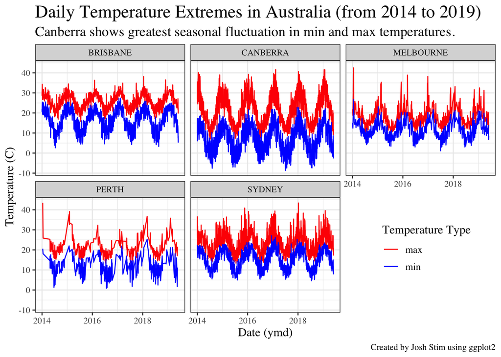

```r
df %>%
  filter(year >= 2014) %>%
  ggplot(aes(x = date, y = temperature, color = temp_type)) +
  facet_wrap(~city_name) +
  geom_line() +
  labs(
    title = "Daily Temperature Extremes in Australia (from 2014 to 2019)",
    subtitle = "Canberra shows greatest seasonal fluctuation in min and max temperatures.",
    x = "Date (ymd)",
    y = "Temperature (C)",
    color = "Temperature Type",
    caption = "Created by Josh Stim using ggplot2"
  ) +
  scale_color_manual(values = c("red", "blue")) +
  theme_bw() +
  theme(
        plot.title = element_text(hjust = 0, size = 18),
        plot.subtitle = element_text(hjust = 0, size = 14),
        axis.title.x = element_text(size = 12),
        axis.title.y = element_text(size = 12),
        text = element_text(family = "Times"),
        legend.title = element_text(size = 12),
        legend.text = element_text(size = 10),
        legend.position = c(0.85,0.25)
        )
```

### (b) Plotting rainfall over time

Here we want to explore the distribution of rainfall (log scale) with histograms for a given city (indicated by the `city_name` column) for a given year (indicated by the `year` column) so we can make some exploratory plots of the data.

The aim here is to design and implement a function that can be re-used to visualize all of the data in this dataset.

1. There are 2 aspects that may vary in the dataset: The `city_name` and the `year`. Note that not all combinations of city_name and year have measurements.
2. Your function should take as input two arguments city_name and year.
3. Given the input from the user, your function should return a single histogram for that input. Furthermore, the data should be readable on that plot so that it is in fact useful. It should be possible visualize the entire dataset with your function (through repeated calls to your function).
4. If the user enters an input that does not exist in the dataset, your function should catch that and report an error (via the `stop()` function).

For this section,

1. Write a short description of how you chose to design your function and why.
2. Present the code for your function in the R markdown document.
3. Include at least one example of output from your function.

**Josh:** I want my function to be robust to invalid inputs and provide informative error messages if something goes wrong. To do this, I used the `assert_that()` function from the `assertthat` package. Essentially, `assert_that()` expands on the `stopifnot()` function, in that it allows the coder to specify an error message when a condition is not met. Error handling of `plot_rainfall_hist` will be demonstrated below. Beyond error handling, I wanted this function to make a histogram with a different subtitle for every `city_name` and `year` combination. That is, for any `city_name` and `year` that the user inputs, the function should output a histogram with a subtitle that reports the number of measurements that reported some rainfall (> 0 mm) as well as the range of `rainfall` in `city_name` and `year`.

**Josh:** Below is the code for `plot_rainfall_hist`.

```r
plot_rainfall_hist <- function(cityname, yr) {

  ##############################################################################
  # Check that `df` exists and contains `city_name` and `year` variables.
  # Throw an error if either condition is not met.
  ##############################################################################

  assertthat::assert_that(
    exists("df"),
    msg = "Dataframe `df` does not exist in your local environment!")

  assertthat::assert_that(
    "city_name" %in% colnames(df) & "year" %in% colnames(df),
    msg = "`city_name` and `year` must be variables in `df`.")

  ##############################################################################
  # Modify `df` to include only data from the specified city name and year.
  # Throw an error if data does not exist.
  ##############################################################################

  tmp_df <- filter(df, city_name == cityname & year == yr)

  assertthat::assert_that(
    nrow(tmp_df) > 0,
    msg = paste0("Could not find rainfall data for ", cityname, " in ", as.character(yr), "!"))

  ##############################################################################
  # Make table summarizing our rainfall data for `cityname` and `yr`. This will
  # make it easier to annotate our histogram.
  ##############################################################################
  rain.table <- tmp_df %>%
    summarize(n = n(),
              n_precip = sum(rainfall > 0),
              n_noprecip = sum(rainfall == 0),
              min_precip = min(rainfall[rainfall > 0]),
              max_precip = max(rainfall),
              min_precip_log = log(min_precip),
              max_precip_log = log(max_precip)
              )

  ##############################################################################
  # Plot histogram of log(rainfall) for specified city name and year.
  ##############################################################################

  rain.hist <- tmp_df %>%
    ggplot(aes(x = log(rainfall))) +
    geom_histogram(color = "black", fill = "lightblue") +
    labs(title = paste("log(rainfall) for", cityname, "in", as.character(yr)),
         subtitle = paste0("Of the ", as.character(rain.table$n), " measurements taken in ", as.character(yr), ", ", as.character(rain.table$n_precip), " reported rainfall.\nRainfall ranged from ", as.character(rain.table$min_precip), " to ", as.character(rain.table$max_precip), " mm [", as.character(round(rain.table$min_precip_log,2)), " to ", as.character(round(rain.table$max_precip_log,2)), " log(mm)]."),
         caption = "Created by Josh Stim using ggplot2") +
    theme_bw() +
    theme(
      text = element_text(family = "Times"),
      plot.title = element_text(hjust = 0, size = 20),
      plot.subtitle = element_text(size = 12),
      axis.title.x = element_text(size = 14),
      axis.title.y = element_text(size = 14)
      )

  rain.hist
  #grid.arrange(rain.hist, rain.table, nrow = 1)
}
```

**Josh:** Below is a demonstration of `plot_rainfall_hist` using `city_name = "PERTH"` and `year = 2010`.

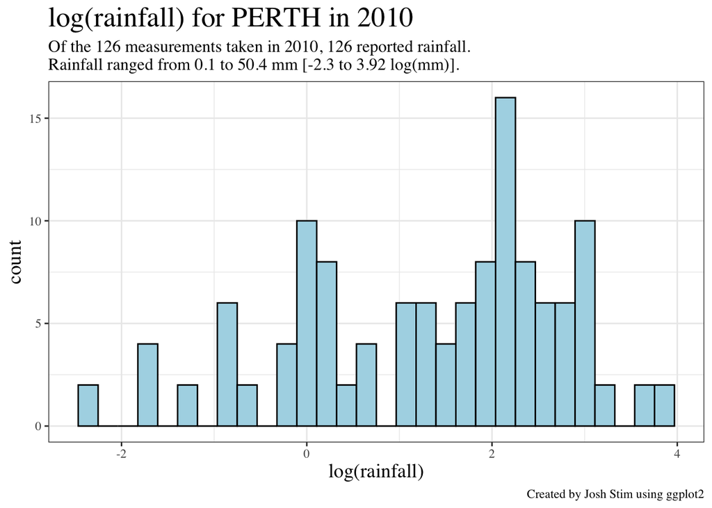

```r
plot_rainfall_hist("PERTH", 2010)
```

**Josh:** Below is a demonstration of error handling performed by `plot_rainfall_hist`.

```r
tryCatch(
  expr = {plot_rainfall_hist("SYDNEY", 1901)},         # there are no recordings from the year 1901
  error = function(e) {print(e)}
)
```

```
## <assertError: Could not find rainfall data for SYDNEY in 1901!>
```

## Part 4. Apply Functions and Plot

### (a) Tasks

In this part, we will apply the functions we wrote in Part 1 to our rainfall data starting with our wrangled `df` data from Part 2.

1. First, filter for only years including 2014 and onwards.
2. For a given city and for a given year, calculate the sample mean (using your function `sample_mean()`), the sample standard deviation (using your function `sample_sd()`), and a 95% confidence interval for the average rainfall (using your function `calculate_CI()`). Specifically, you should add two columns in this summarized dataset: a column titled `lower_bound` and a column titled `upper_bound` containing the lower and upper bounds for you CI that you calculated (using your function `calculate_CI()`).
3. Call this summarized dataset `rain_df`.

**Josh:** Below is the summarized dataset `rain_df`.

```r
rain_df <- df %>%
  filter(year >= 2014) %>%
  group_by(city_name, year) %>%
  summarize(n = n(),
            sample.mean = sample_mean(rainfall),
            sample.sd = sample_sd(rainfall),
            CI.95.lower = calculate_CI(rainfall)[1],
            CI.95.upper = calculate_CI(rainfall)[2])
rain_df
```

```
## # A tibble: 30 × 7
## # Groups:   city_name [5]
##    city_name  year     n sample.mean sample.sd CI.95.lower CI.95.upper
##    <chr>     <dbl> <int>       <dbl>     <dbl>       <dbl>       <dbl>
##  1 BRISBANE   2014   802        3.84     12.3         2.99        4.69
##  2 BRISBANE   2015   740        6.17     22.7         4.53        7.82
##  3 BRISBANE   2016   726        2.09      8.61        1.47        2.72
##  4 BRISBANE   2017   712        2.72     10.2         1.97        3.47
##  5 BRISBANE   2018   696        2.47      9.63        1.75        3.19
##  6 BRISBANE   2019   300        2.10      6.35        1.38        2.82
##  7 CANBERRA   2014   724        1.57      4.84        1.22        1.92
##  8 CANBERRA   2015   722        1.51      5.16        1.13        1.89
##  9 CANBERRA   2016   732        2.15      6.28        1.70        2.61
## 10 CANBERRA   2017   726        1.34      4.12        1.04        1.64
## # ℹ 20 more rows
```

### (b) Tasks

Using the `rain_df`, plots the estimates of mean rainfall and the 95% confidence intervals on the same plot. There should be a separate faceted plot for each city. Think about using `ggplot()` with both `geom_point()` (and `geom_line()` to connect the points) for the means and geom_errorbar() for the lower and upper bounds of the confidence interval. Check https://r-graphics.org/recipe-annotate-error-bar and or the official documentation https://ggplot2.tidyverse.org/reference/geom_linerange.html for examples of how to use `geom_errorbar()`.

**Josh:** Below is a line plot summarizing average rainfall from 2014 - 2019 in select Australian cities.

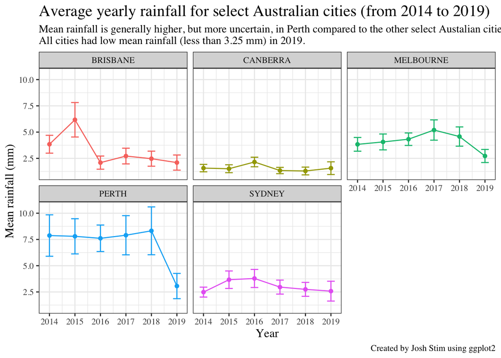

```r
rain_df %>%
  ggplot(aes(x = year, y = sample.mean, color = city_name)) +
  geom_point() +
  geom_line() +
  geom_errorbar(aes(ymin = CI.95.lower, ymax = CI.95.upper), width = 0.3) +
  facet_wrap(~city_name) +
  labs(title = "Average yearly rainfall for select Australian cities (from 2014 to 2019)",
       subtitle = "Mean rainfall is generally higher, but more uncertain, in Perth compared to the other select Austalian cities. \nAll cities had low mean rainfall (less than 3.25 mm) in 2019.",
       x = "Year",
       y = "Mean rainfall (mm)",
       caption = "Created by Josh Stim using ggplot2"
       ) +
  theme_bw() +
  theme(
    plot.title = element_text(hjust = 0, size = 16),
    plot.subtitle = element_text(hjust = 0),
    axis.title.x = element_text(size = 12),
    axis.title.y = element_text(size = 12),
    legend.position = 'none',
    text = element_text(family = "Times")
    )
```

```r
options(width = 120)
```